# Tennis HMMs

# Federer’s Matches in Aus Open 2017

This project looks at using Hidden Markov Models to identify Federer’s shot intentions during the Australian Open, 2017.

Using two hidden states, shots intentions can be categorized as ‘return’, meaning the shot was just meant to be returned to the opponent, and ‘winner’ or ‘aggressive’, meaning that the intention of the shots was to win the point with that shot.

The depmixS4 package includes the function depmix, which is used for estimation of this particular hidden markov model.

```r
library(devtools)
load("/Users/Jeremy/Documents/Winter Project/intentions/data/federer2017.RData")
library(ggplot2)
library(tidyr)
library(dplyr)
library(readr)
```

## Shaping and manipulating the data. Adding new variables.

Adding new variables that are manipulations of the information contained in the datatset.

```r
fed_df <- federer2017
fed_df <- arrange(fed_df, matchid, set, game, point, shot)
#Reorienting shots so that all Federer's shot are from negative x side of court, and all opponents shots are from positive x side. y coordinates have been flipped as required.
#Federer
fed_df <- fed_df %>% rowwise %>%
  mutate(ballmark.x = ifelse(impact.player == "FEDERER" & start.x >= 0, -ballmark.x, ballmark.x)) %>%
  mutate(ballmark.y = ifelse(impact.player == "FEDERER" & start.x >= 0, -ballmark.y, ballmark.y)) %>%
  mutate(start.y = ifelse(impact.player == "FEDERER" & start.x >= 0, -start.y, start.y)) %>%
  mutate(final.x = ifelse(impact.player == "FEDERER" & start.x >= 0, -final.x, ballmark.x)) %>%
  mutate(final.y = ifelse(impact.player == "FEDERER" & start.x >= 0, -final.y, ballmark.y)) %>%
  mutate(start.x = ifelse(impact.player == "FEDERER" & start.x >= 0, -start.x, start.x))
#Opponents
fed_df <- fed_df %>% rowwise %>%
  mutate(start.y = ifelse(impact.player != "FEDERER" & start.x <= 0, -start.y, start.y)) %>%
  mutate(ballmark.x = ifelse(impact.player != "FEDERER" & start.x <= 0, -ballmark.x, ballmark.x)) %>%
  mutate(ballmark.y = ifelse(impact.player != "FEDERER" & start.x <= 0, -ballmark.y, ballmark.y)) %>%
  mutate(final.x = ifelse(impact.player != "FEDERER" & start.x <= 0, -final.x, ballmark.x)) %>%
  mutate(final.y = ifelse(impact.player != "FEDERER" & start.x <= 0, -final.y, ballmark.y)) %>%
  mutate(start.x = ifelse(impact.player != "FEDERER" & start.x <= 0, -start.x, start.x))
#Adding Vars
fed_df <- fed_df %>%
  mutate(lastshot = ifelse(shot == final.shot,1,0)) %>%
  mutate(isserver = ifelse(server == impact.player,1,0)) %>%
  mutate(fhand = ifelse(hitpoint == "F",1,0)) %>%
  mutate(opponent = ifelse(server == "FEDERER", receiver, server))
fed_df <- fed_df %>%
  mutate(winner = ifelse(ended.in.error == FALSE & lastshot == 1,1,0)) %>%
  mutate(retser = ifelse(shot == 2,1,0)) %>%
  mutate(retser1 = ifelse(shot == 2 & serve.classification == 1,1,0)) %>%
  mutate(retser2 = ifelse(shot == 2 & serve.classification == 2,1,0))
for (i in 1:ncol(fed_df)) {
  if(is.character(fed_df[,i]) == TRUE) {
    fed_df[,i] <- as.factor(fed_df[,i])
  }
}
```

```r
library(stringi)
ids <- fed_df$id
split.ids <- t(data.frame(stri_split_boundaries(ids, type="character")))
fed_df <- fed_df %>%
  plyr::mutate(server.points = split.ids[,1], receiver.points = split.ids[,2], server.games = split.ids[,3], receiver.games = split.ids[,4], server.sets = split.ids[,5], receiver.sets = split.ids[,6])
#Now mutate this to Federer score and opponent score
fed_df <- fed_df %>% rowwise %>%
  mutate(fed.points = ifelse(server == "FEDERER", as.numeric(server.points), as.numeric(receiver.points))) %>%
  mutate(fed.games = ifelse(server == "FEDERER", as.numeric(server.games), as.numeric(receiver.games))) %>%
  mutate(fed.sets = ifelse(server == "FEDERER", as.numeric(server.sets), as.numeric(receiver.sets))) %>%
  mutate(opp.points = ifelse(server == "FEDERER", as.numeric(receiver.points), as.numeric(server.points))) %>%
  mutate(opp.games = ifelse(server == "FEDERER", as.numeric(receiver.games), as.numeric(server.games))) %>%
  mutate(opp.sets = ifelse(server == "FEDERER", as.numeric(receiver.sets), as.numeric(server.sets)))
fed_df <- fed_df %>%
    mutate(sets.diff = fed.sets - opp.sets) %>%
    mutate(games.diff = fed.games - opp.games) %>%
    mutate(points.diff = fed.points - opp.points)
```

```r
fed_df <- fed_df %>%
  mutate(speed.diff = NA) %>%
  mutate(oppo.hit.x = NA) %>%
  mutate(oppo.hit.y = NA) %>%
  mutate(oppo.hit.z = NA) %>%
  mutate(oppo.speed = NA) %>%
  mutate(oppo.ballmark.x = NA) %>%
  mutate(oppo.ballmark.y = NA) %>%
  mutate(speed.ratio = NA)
for (i in 2:nrow(fed_df)) {
  if(fed_df$shot[i] != 1) {#so that only non-serves are affected
  fed_df$speed.diff[i]=fed_df$speed1[i]-fed_df$speed1[i-1]
  #speed difference

  fed_df$oppo.hit.x[i]=fed_df$start.x[i-1]
  fed_df$oppo.hit.y[i]=fed_df$start.y[i-1]
  fed_df$oppo.hit.z[i]=fed_df$start.z[i-1]
  fed_df$oppo.speed[i]=fed_df$speed1[i-1]
  fed_df$oppo.ballmark.x[i]=fed_df$ballmark.x[i-1]
  fed_df$oppo.ballmark.y[i]=fed_df$ballmark.y[i-1]
  #oppo hit

  }
}
fed_df <- fed_df %>%
  mutate(speed.ratio = speed1/oppo.speed) %>% #speed ratio
  mutate(side.dist = 4.115 - abs(oppo.ballmark.y)) %>% #distance of oppo.ballmark from sideline
  mutate(base.dist = 11.89 - abs(oppo.ballmark.x)) %>% #distance of oppo.ballmark from baseline
  mutate(short.dist = min(side.dist, base.dist)) #shortest distance from any line
#Adding angles
fed_df <- fed_df %>%
  mutate(p.start.x = NA) %>%
  mutate(p.start.y = NA)
for (i in 3:nrow(fed_df)) {
  if(fed_df$impact.player[i] == fed_df$impact.player[i-2] & fed_df$shot[i] == fed_df$shot[i-2] + 2) {
    fed_df$p.start.x[i]=fed_df$start.x[i-2]
    fed_df$p.start.y[i]=fed_df$start.y[i-2]
  }
}
#adding angle between fed.shot-opp.shot vector and opp.shot-opp.ballmark vector
#doing it in one line because df doesn't want to add vectors
fed_df <- fed_df %>%
  mutate(o.angle = NA)

for (i in 1:nrow(fed_df)) {
  x1 <- fed_df$p.start.x[i]
  y1 <- fed_df$p.start.y[i]
  x2 <- fed_df$oppo.hit.x[i]
  y2 <- fed_df$oppo.hit.y[i]
  x3 <- fed_df$oppo.ballmark.x[i]
  y3 <- fed_df$oppo.ballmark.y[i]

  o.angle <- acos(
  ((c(x1,y1)-c(x2,y2))/sqrt((x1-x2)^2+(y1-y2)^2)) %*%
    ((c(x2,y2)-c(x3,y3))/sqrt((x2-x3)^2+(y2-y3)^2))) * 180/pi

  fed_df$o.angle[i] = ifelse(o.angle > 90, 180-o.angle, o.angle)
}
#Now adding the angle the player hits
fed_df <- fed_df %>%
  mutate(p.angle = NA)

for (i in 1:nrow(fed_df)) {
  x1 <- fed_df$oppo.hit.x[i]
  y1 <- fed_df$oppo.hit.y[i]
  x2 <- fed_df$start.x[i]
  y2 <- fed_df$start.y[i]
  x3 <- fed_df$ballmark.x[i]
  y3 <- fed_df$ballmark.y[i]

  p.angle <- acos(
  ((c(x1,y1)-c(x2,y2))/sqrt((x1-x2)^2+(y1-y2)^2)) %*%
    ((c(x2,y2)-c(x3,y3))/sqrt((x2-x3)^2+(y2-y3)^2))) * 180/pi

  fed_df$p.angle[i] = ifelse(p.angle > 90, 180-p.angle, p.angle)
}
fed_df <- fed_df %>%
  mutate(lag.p.angle = 0) %>%
  mutate(lag.speed.ratio = 0)
#Add p.angle and speed ratio of prior shot
for (i in 3:nrow(fed_df)) {
  fed_df$lag.p.angle[i] = ifelse(fed_df$impact.player[i]==fed_df$impact.player[i-2] & fed_df$shot[i] >= 4, fed_df$p.angle[i-2], 0)
  fed_df$lag.speed.ratio[i] = ifelse(fed_df$impact.player[i]==fed_df$impact.player[i-2] & fed_df$shot[i] >= 4, fed_df$speed.ratio[i-2], 0)
}
```

### Glossary of Added Variables

lastshot - last shot in the point

fedhit - federer hits the shot

isserver - if server hits the shot

winner - if shot is winner (i.e. point doesn’t end in error, as opponent doesn’t reach the ball)

retser - if shot is returning serve

retser1 - if shot is returning first serve

retser2 - if shot is returning second serve

speed.diff - difference in current shot speed vs opponents last shot speed (at impact)

speed.ratio - shot speed/opponent’s previous shot speed

speed1 - speed of shot from impact with racquet

o.angle - angle made by opponents previous shot

p.angle - angle made by player’s current shot

lag.p.angle - angle made by player’s previous shot in rally

lag.speed.ratio - speed ratio of player’s previous in rally

oppo.hit - coordinates of opponents previous impact

fed.points/games/sets - fed score up to current point

opp.points/games/sets - opponent score up to current point

points/games/sets.diff - difference in score from Federer’s perspective

```r
#remove opponents
fed_no.opp <- fed_df %>%
  dplyr::filter(impact.player == "FEDERER")
#federer only - remove serves
fed_only <- fed_no.opp %>%
  filter(hitpoint != "S") %>%
  dplyr::select(-serveid)
#First remove any errors for start, ballmark, so that we are only looking at shots that we hit onto the other side
#To check: ggplot(fed_only, aes(ballmark.x, ballmark.y)) + geom_point()
fed_only <- fed_only %>%
  filter(oppo.hit.x >= 0) %>%
  filter(oppo.ballmark.x <= 0) %>%
  filter(ballmark.x >= 0)
#Adding shot number cumulative count (functions as time)
fed_only <- fed_only %>%
  mutate(count = 1)
  for (i in 2:nrow(fed_only)) {
    if(fed_only$matchid[i]==fed_only$matchid[i-1]) {
      fed_only$count[i] = fed_only$count[i-1] + 1
    }
  }
#Adjusting to remove NAs and replace with 0s for modelling
fed_only$o.angle[is.na(fed_only$o.angle)] <- 0
```

## Modelling

After a visual analysis of interaction between variables in the dataset, the response variables and covariates must be selected for the model.

Response variables are what we see occur as a result of Federer’s hidden state. The primary candidates for the models are: winner, speed.ratio and p.angle.

Covariates are factors that occur up to the time of the shot, and affect the transition probabilities from/to each hidden state. The covariates selected for modelling after visual examination are: oppo.speed, retser1, retser2, start.x, o.angle, oppo.hit.x, lag.p.angle, lag.speed.ratio, points.diff, games.diff, sets.diff

## Model Types

Models are broken down into three types. The first are simple models, independent of match score, the second are more detailed models, independent of match score and the third are detailed models, dependent on match score.

## Model Decision

The two best models by comparing AIC values were Type 2, Model 1 and Type 3, Model 4. The latter is just the former plus covariates for the difference in points, games and sets.

Because the difference in AIC between these models is so small, and the -logLik is lower for Type 3 Model 4, I have decided to include points, games and set difference in the model for the sake of examining other players.

Part of the rationale for this decision is that other players may behave differently with different score differentials, even if Federer may be able to block out the score in a match and play consistantly throughout. For the sake of modelling other players in the future, the score dependent model (T3M4) is selected, even though it is not a significant improvement on the score independent model (T2M1).

Overall: The decision is to proceed with Model 4 from Type 3 category.

Response variables: winner, speed.ratio

Covariates: oppo.speed, retser1, retser2, start.x, o.angle, oppo.hit.x, lag.p.angle, lag.speed.ratio, points.diff, games.diff, sets.diff

```r
library(depmixS4)
t3.mod4 <- depmix(list(winner ~ 1, speed.ratio ~ 1), transition = ~ oppo.speed + retser1 + retser2 + start.x + o.angle + oppo.hit.x + lag.p.angle + lag.speed.ratio + points.diff + games.diff + sets.diff, data = fed_only, nstates = 2, family=list(multinomial("identity"),gaussian()))
t3.fm4<- fit(t3.mod4)
```

```
iteration 0 logLik: -1723.961
iteration 5 logLik: -1537.257
iteration 10 logLik: -1498.618
iteration 15 logLik: -1492.558
iteration 20 logLik: -1489.066
iteration 25 logLik: -1487.191
iteration 30 logLik: -1486.218
iteration 35 logLik: -1485.701
iteration 40 logLik: -1485.419
iteration 45 logLik: -1485.246
iteration 50 logLik: -1485.127
iteration 55 logLik: -1485.038
iteration 60 logLik: -1484.969
iteration 65 logLik: -1484.914
iteration 70 logLik: -1484.874
iteration 75 logLik: -1484.847
iteration 80 logLik: -1484.828
iteration 85 logLik: -1484.816
iteration 90 logLik: -1484.81
iteration 95 logLik: -1484.807
iteration 100 logLik: -1484.804
iteration 105 logLik: -1484.803
iteration 110 logLik: -1484.803
iteration 115 logLik: -1484.802
converged at iteration 116 with logLik: -1484.802
```

```r
summary(t3.fm4)
```

```
Initial state probabilties model
pr1 pr2
  1   0

Transition model for state (component) 1
Model of type multinomial (mlogit), formula: ~oppo.speed + retser1 + retser2 + start.x + o.angle + oppo.hit.x +
    lag.p.angle + lag.speed.ratio + points.diff + games.diff +
    sets.diff
Coefficients:
                St1         St2
(Intercept)       0  0.96836770
oppo.speed        0  0.01956451
retser1           0  0.04384919
retser2           0 -1.65759430
start.x           0  0.12132775
o.angle           0 -0.01182551
oppo.hit.x        0 -0.12657671
lag.p.angle       0  0.10254026
lag.speed.ratio   0 -0.98283501
points.diff       0 -0.19401213
games.diff        0  0.03274344
sets.diff         0  0.41313966
Probalities at zero values of the covariates.
0.275206 0.724794

Transition model for state (component) 2
Model of type multinomial (mlogit), formula: ~oppo.speed + retser1 + retser2 + start.x + o.angle + oppo.hit.x +
    lag.p.angle + lag.speed.ratio + points.diff + games.diff +
    sets.diff
Coefficients:
                St1          St2
(Intercept)       0  -1.46841029
oppo.speed        0   0.06974129
retser1           0  -3.68879248
retser2           0 -10.60136233
start.x           0   0.17753616
o.angle           0  -0.04363081
oppo.hit.x        0   0.13026016
lag.p.angle       0  -0.30873636
lag.speed.ratio   0   0.13303360
points.diff       0   0.95229084
games.diff        0   0.10022562
sets.diff         0   0.04220290
Probalities at zero values of the covariates.
0.8128156 0.1871844


Response parameters
Resp 1 : multinomial
Resp 2 : gaussian
    Re1.0 Re1.1 Re2.(Intercept) Re2.sd
St1 0.956 0.044           0.819  0.275
St2 0.710 0.290           1.326  0.521
```

### Interpreting the output

The response parameters tell us about the characteristics of each state. What is found is that when two states are specified, they meet the criteria of ‘winner’ and ‘return’ as we expect.

State 1 is a ‘returning’ state, where the probability of hitting a winner is 0.044, and the speed.ratio of shots are 0.819, on average. This indicates slower shots with more conservative approach.

State 2 is a ‘winning’ or ‘aggressive’ state, where the probability of hitting a winner is 0.29, and the speed.ratio of shots are 1.326, on average.

Not only is this confirming our qualitative intuition, but it is telling us about how Federer behaves in matches, and shows that there is a clear difference between his shot intentions.

A limitation of this analysis is that it is examining only two states. Further analysis would consider more states to help classification. For example, if four states were used, there may be two returning states, one faster than the other, and two aggressive states, with one very fast, and one very slow (i.e. drop shots).

# Predictions with Model

```r
#Pull out parameters
pars <- getpars(t3.fm4)
#Creating temporary transition matrix
#Refresh function: Inputs
#a - oppo.speed
#b - retser1
#c - retser2
#d - start.x
#e - o.angle
#f - oppo.hit.x
#g - lag.p.angle
#h - lag.speed.ratio
#j - points.diff
#k - games.diff
#l - sets.diff
tr.refresh <- function(a,b,c,d,e,f,g,h,j,k,l) {
  p11 <- 1/(1+exp(pars[[4]]+pars[[6]]*a+pars[[8]]*b+pars[[10]]*c+pars[[12]]*d+pars[[14]]*e+pars[[16]]*f+pars[[18]]*g+pars[[20]]*h+pars[[22]]*j+pars[[24]]*k+pars[[26]]*l))

  p21 <- 1/(1+exp(pars[[28]]+pars[[30]]*a+pars[[32]]*b+pars[[34]]*c+pars[[36]]*d+pars[[38]]*e+pars[[40]]*f+pars[[42]]*g+pars[[44]]*h+pars[[46]]*j+pars[[48]]*k+pars[[50]]*l))

  p12 <- 1 - p11
  p22 <- 1 - p21

  tr.temp <- as.matrix(c(p11,p21,p12,p22))
  tr.temp <- matrix(tr.temp, ncol=2)
}
#Predicted states shell
pr.state <- matrix(0,nrow(fed_only),2)
#State 1
init.state <- matrix(c(pars[[1]],pars[[2]]),ncol=2) #initial state
a <- fed_only$oppo.speed[1]
b <- fed_only$retser1[1]
c <- fed_only$retser2[1]
d <- fed_only$start.x[1]
e <- fed_only$o.angle[1]
f <- fed_only$oppo.hit.x[1]
g <- fed_only$lag.p.angle[1]
h <- fed_only$lag.speed.ratio[1]
j <- fed_only$points.diff[1]
k <- fed_only$games.diff[1]
l <- fed_only$sets.diff[1]
trans <- tr.refresh(a,b,c,d,e,f,g,h,j,k,l)
pr.state[1,] <- init.state %*% trans
#States 2 onwards (holding probabilities)
for(i in 2:nrow(fed_only)) {
a <- fed_only$oppo.speed[i]
b <- fed_only$retser1[i]
c <- fed_only$retser2[i]
d <- fed_only$start.x[i]
e <- fed_only$o.angle[i]
f <- fed_only$oppo.hit.x[i]
g <- fed_only$lag.p.angle[i]
h <- fed_only$lag.speed.ratio[i]
j <- fed_only$points.diff[i]
k <- fed_only$games.diff[i]
l <- fed_only$sets.diff[i]
  trans <- tr.refresh(a,b,c,d,e,f,g,h,j,k,l)
  pr.state[i,] <- pr.state[i-1,] %*% trans
}
#Predicted states - also adjusts to make sure it selects correct state
if (pars[[52]] >= pars [[56]]) {
  predict_df <- data.frame(prob.win=pr.state[,1])
} else {
  predict_df <- data.frame(prob.win=1-pr.state[,1])
}
#Making conclusions on state
predict_df <- predict_df %>% rowwise %>%
  mutate(pred.win = ifelse(prob.win <= 0.5, 0, 1))
fed_pred <- cbind(fed_only, predict_df)
#Remember that state 1 is winner, state 2 is returning
```

Now plotting the probabilities for each shot, for every game

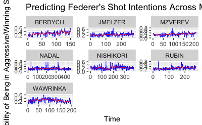

```r
ggplot(fed_pred, aes(x=count,y=prob.win)) + geom_line(color="blue", size=0.3) + geom_smooth(span = 0.1, se=FALSE, color="red", size = 0.4) + facet_wrap(~factor(opponent), scale="free") + xlab("Time") + ylab("Probability of Being in Aggressive/Winning State") + ggtitle("Predicting Federer's Shot Intentions Across Matches in the 2017 Australian Open")
```

This plot shows the probability of being in a ‘winning’ or ‘aggressive’ state throughout each of Federer’s matches. The red lines are fitted lines that give us a lower resolution picture of Federer’s behaviour throughout the games.

Further visualization involving faceting with other variables may give more insight into Federer’s behavior. There was difficultly faceting by opponent and by other variables.

### Extension: Round 3 vs. Berdych

For the sake of more visualization, let’s consider Federer’s game against Berdych. This match is chosen because the probability of being in aggressive state increases as the game goes on (i.e. upwards trend).

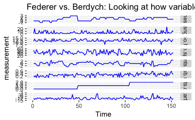

# Appendix

This contains all models run in determining best fit, and the visual plots.

## Visualization of Variables

Here are a series of plots which give us an idea of how each variable affects hitting a winner.

Looking at these plots, we try to determine which variables may be used as response variables, meaning that they make up part of the state classification, or as a covariate, meaning they affect the likelihood of being in a state.

### Coordinates, speed and angles of shots from both Federer and opponents

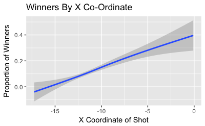

```r
##Plots of shot and ballmark co-ordinates, angles made by shots and speed measures
library(ggplot2)
#X Co-ordinate of shot
ggplot(fed_only, aes(x=start.x,winner)) + geom_smooth() + xlab("X Coordinate of Shot") + ylab("Proportion of Winners") + ggtitle("Winners By X Co-Ordinate")
```

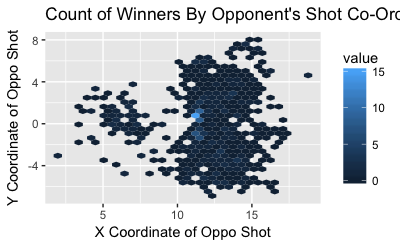

```r
#Opponents shot before
library(hexbin)
ggplot(fed_only, aes(x=oppo.hit.x,y=oppo.hit.y,z=winner)) + stat_summary_hex(fun = function(winner) sum(winner)) + xlab("X Coordinate of Oppo Shot") + ylab("Y Coordinate of Oppo Shot") + ggtitle("Count of Winners By Opponent's Shot Co-Ordinates")
```

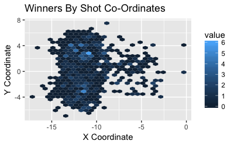

```r
### Get help transforming this to proportion in each bin instead of raw count
#Fed Shots on x-y plane
ggplot(fed_only, aes(x=start.x,y=start.y,z=winner)) + stat_summary_hex(fun = function(winner) sum(winner)) + xlab("X Coordinate") + ylab("Y Coordinate") + ggtitle("Winners By Shot Co-Ordinates")
```

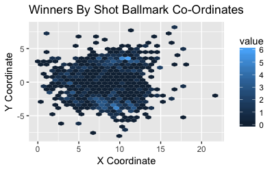

```r
#Fed Ballmark by winner in x-y plane
ggplot(fed_only, aes(x=ballmark.x,y=ballmark.y,z=winner)) + stat_summary_hex(fun = function(winner) sum(winner)) + xlab("X Coordinate") + ylab("Y Coordinate") + ggtitle("Winners By Shot Ballmark Co-Ordinates")
```

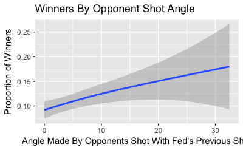

```r
#Angle of shots
ggplot(fed_only, aes(x=o.angle,y=winner)) + geom_smooth() + xlab("Angle Made By Opponents Shot With Fed's Previous Shot") + ylab("Proportion of Winners") + ggtitle("Winners By Opponent Shot Angle")
```

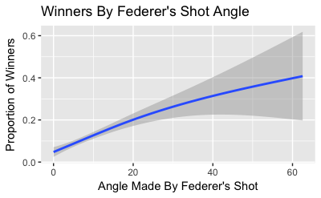

```r
ggplot(fed_only, aes(x=p.angle,y=winner)) + geom_smooth() + xlab("Angle Made By Federer's Shot") + ylab("Proportion of Winners") + ggtitle("Winners By Federer's Shot Angle")
```

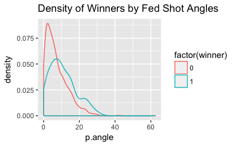

```r
ggplot(fed_only) + geom_density(aes(p.angle,group=factor(winner),color=factor(winner))) + ggtitle("Density of Winners by Fed Shot Angles")
```

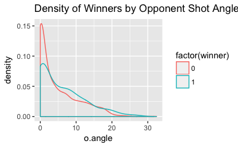

```r
ggplot(fed_only) + geom_density(aes(o.angle,group=factor(winner),color=factor(winner))) + ggtitle("Density of Winners by Opponent Shot Angles")
```

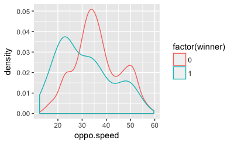

```r
#Winners by oppo speed
ggplot(fed_only) + geom_density(aes(oppo.speed, group = factor(winner), color=factor(winner)))
```

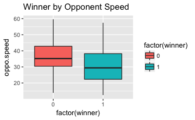

```r
ggplot(fed_only, aes(x=factor(winner),y=oppo.speed,fill=factor(winner))) + geom_boxplot() + ggtitle("Winner by Opponent Speed")
```

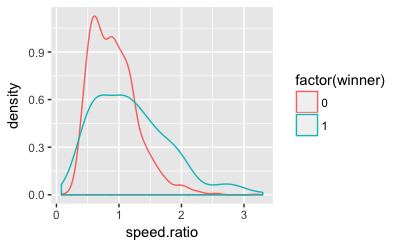

```r
#Winners by speed ratio
ggplot(fed_only) + geom_density(aes(speed.ratio, group = factor(winner), color=factor(winner)))
```

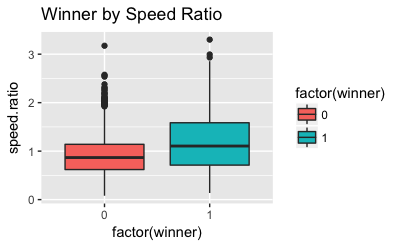

```r
ggplot(fed_only, aes(x=factor(winner),y=speed.ratio,fill=factor(winner))) + geom_boxplot() + ggtitle("Winner by Speed Ratio")
```

### Looking at differences in speed for winners across match situations/scores

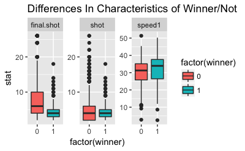

```r
#Box plots across multiple categories
df_long1 <- gather(data = fed_only, key = variables, value = stat, speed1, final.shot, shot)
ggplot(df_long1) + geom_boxplot(aes(x=factor(winner), y=stat, fill=factor(winner))) + facet_wrap(~variables, scale = "free_y") + ggtitle("Differences In Characteristics of Winner/Not")
```

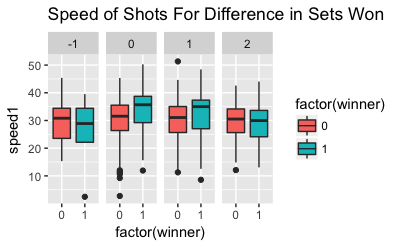

```r
#Boxplots for speed by winner, facet by sets difference
ggplot(fed_only, aes(x=factor(winner),y=speed1,fill=factor(winner))) + geom_boxplot() + facet_grid(.~ sets.diff) + ggtitle("Speed of Shots For Difference in Sets Won")
```

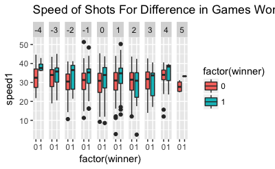

```r
#Boxplots for speed by winner, facet by games difference
ggplot(fed_only, aes(x=factor(winner),y=speed1,fill=factor(winner))) + geom_boxplot() + facet_grid(.~ games.diff) + ggtitle("Speed of Shots For Difference in Games Won")
```

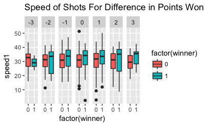

```r
#Boxplots for speed by winner, facet by points difference
ggplot(fed_only, aes(x=factor(winner),y=speed1,fill=factor(winner))) + geom_boxplot() + facet_grid(.~ points.diff) + ggtitle("Speed of Shots For Difference in Points Won")
```

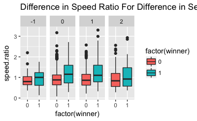

```r
#Boxplots for speed.ratio by winner, facet by sets difference
ggplot(fed_only, aes(x=factor(winner),y=speed.ratio,fill=factor(winner))) + geom_boxplot() + facet_grid(.~ sets.diff) + ggtitle("Difference in Speed Ratio For Difference in Sets Won")
```

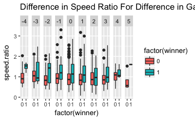

```r
#Boxplots for speed.ratio by winner, facet by games difference
ggplot(fed_only, aes(x=factor(winner),y=speed.ratio,fill=factor(winner))) + geom_boxplot() + facet_grid(.~ games.diff) + ggtitle("Difference in Speed Ratio For Difference in Games Won")
```

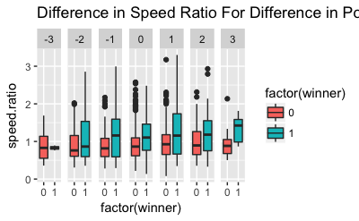

```r
#Boxplots for speed.ratio by winner, facet by points difference
ggplot(fed_only, aes(x=factor(winner),y=speed.ratio,fill=factor(winner))) + geom_boxplot() + facet_grid(.~ points.diff) + ggtitle("Difference in Speed Ratio For Difference in Points Won")
```

### Winners by forehand/backhand, return serve classifcations and the effect of importance (metric)

```r
#Proportion of winners by forehand/backhand
fed_hand <- na.omit(fed_only) %>%
  group_by(hitpoint,winner) %>%
  summarise(n=n()) %>%
  mutate(proportion = n/sum(n))
ggplot(fed_hand, aes(x=factor(winner),y=proportion,color=factor(winner))) + geom_point() + facet_grid(~hitpoint,labeller = label_both) + ggtitle("Proportion of Winners for Backhand/Forehand Shots")

#Proportion of winners for returning serve
fed_ret <- fed_only %>%
  group_by(retser,retser1,winner) %>%
  summarise(n=n()) %>%
  mutate(proportion = n/sum(n))
ggplot(fed_ret, aes(x=factor(winner),y=proportion,color=factor(winner))) + geom_point() + facet_wrap(~retser ~retser1,labeller = label_both) + ggtitle("Proportion of Winners for Returning Serve - For Both Serve 1 and 2")

#Plotting Importance
ggplot(fed_only, aes(x=importance,y=winner)) + geom_smooth() + xlab("Importance") + ylab("Proportion of Winners") + labs(title="Proportion of Winners against Importance")

ggplot(fed_only) + geom_density(aes(importance, group = factor(winner), color=factor(winner))) + labs(title="Density of Importance by Winners")
```

[output not shown]

## Type 1: Simple Models, Independent of Match Score/Situation

### T1: Model 1

Response: winner Covariates: oppo.speed, retser1, retser2, start.x

```r
library(depmixS4)
library(dplyr)
t1.mod1 <- depmix(winner ~ 1, transition = ~ oppo.speed + retser1 + retser2 + start.x, data = fed_only, nstates = 2, family=multinomial("identity"))
t1.fm1 <- fit(t1.mod1)
summary(t1.fm1)
```

State 1 is returning as there is 0.052 probability of hitting a winner State 2 is more aggressive, with 0.226 chance of hitting a winner

### T1: Model 2

Response: winner Covariates: oppo.speed, retser1, retser2, start.x, o.angle

```r
library(depmixS4)
t1.mod2 <- depmix(winner ~ 1, transition = ~ oppo.speed + retser1 + retser2 + start.x + o.angle, data = fed_only, nstates = 2, family=multinomial("identity"))
t1.fm2 <- fit(t1.mod2)
summary(t1.fm2)
```

State 1 is returning as there is 0.000 probability of hitting a winner State 2 is more aggressive, with 0.227 chance of hitting a winner

### T1: Model 3

Response: winner Covariates: oppo.speed, retser1, retser2, start.x, o.angle, oppo.hit.x

```r
library(depmixS4)
t1.mod3 <- depmix(winner ~ 1, transition = ~ oppo.speed + retser1 + retser2 + start.x + o.angle + oppo.hit.x, data = fed_only, nstates = 2, family=multinomial("identity"))
t1.fm3<- fit(t1.mod3)
summary(t1.fm3)
```

### T1: Model 4

Response: winner Covariates: oppo.speed, retser1, retser2, start.x, o.angle, oppo.hit.x, oppo.ballmark.x

```r
library(depmixS4)
t1.mod4 <- depmix(winner ~ 1, transition = ~ oppo.speed + retser1 + retser2 + start.x + o.angle + oppo.hit.x + oppo.ballmark.x, data = fed_only, nstates = 2, family=multinomial("identity"))
t1.fm4<- fit(t1.mod4)
summary(t1.fm4)
```

### T1: Model 5

Response: winner Covariates: oppo.speed, retser1, retser2, start.x, o.angle, oppo.hit.x, lag.p.angle, lag.speed.ratio

```r
library(depmixS4)
t1.mod5 <- depmix(winner ~ 1, transition = ~ oppo.speed + retser1 + retser2 + start.x + o.angle + oppo.hit.x + lag.p.angle + lag.speed.ratio, data = fed_only, nstates = 2, family=multinomial("identity"))
t1.fm5 <- fit(t1.mod5)
summary(t1.fm5)
```

### Comparing Type 1 Models

```r
AIC(t1.fm1)
AIC(t1.fm2)
AIC(t1.fm3)
AIC(t1.fm4)
AIC(t1.fm5)

library(lmtest)
lrtest(t1.fm3,t1.fm5)
```

Conclusion: Model 5 has lowest AIC, which is slightly lower than model 3. LR Test confirms that Model 5 is significantly different to Model 3, so we will continue with Model 5’s covariates.

## Type 2: Higher Resolution Models, Independent of Match Score

### T2: Model 1

Response: winner, speed.ratio Covariates: oppo.speed, retser1, retser2, start.x, o.angle, oppo.hit.x, lag.p.angle, lag.speed.ratio

```r
library(depmixS4)
t2.mod1 <- depmix(list(winner ~ 1, speed.ratio ~ 1), transition = ~ oppo.speed + retser1 + retser2 + start.x + o.angle + oppo.hit.x + lag.p.angle + lag.speed.ratio, data = fed_only, nstates = 2, family=list(multinomial("identity"),gaussian()))
t2.fm1<- fit(t2.mod1)
summary(t2.fm1)
```

### T2: Model 2

Response: winner, p.angle Covariates: oppo.speed, retser1, retser2, start.x, o.angle, oppo.hit.x, lag.p.angle, lag.speed.ratio

```r
library(depmixS4)
t2.mod2 <- depmix(list(winner ~ 1, p.angle ~ 1), transition = ~ oppo.speed + retser1 + retser2 + start.x + o.angle + oppo.hit.x + lag.p.angle + lag.speed.ratio, data = fed_only, nstates = 2, family=list(multinomial("identity"),gaussian()))
t2.fm2<- fit(t2.mod2)
summary(t2.fm2)
```

### T2: Model 3

Response: winner, speed.ratio p.angle Covariates: oppo.speed, retser1, retser2, start.x, o.angle, oppo.hit.x, lag.p.angle, lag.speed.ratio

```r
library(depmixS4)
t2.mod3 <- depmix(list(winner ~ 1, speed.ratio ~ 1, p.angle ~ 1), transition = ~ oppo.speed + retser1 + retser2 + start.x + o.angle + oppo.hit.x + lag.p.angle + lag.speed.ratio, data = fed_only, nstates = 2, family=list(multinomial("identity"),gaussian(),gaussian()))
t2.fm3<- fit(t2.mod3)
summary(t2.fm3)
```

Comparing these three to see which combination of response variables is the best fit

```r
AIC(t2.fm1)
AIC(t2.fm2)
AIC(t2.fm3)
```

Model 1 - winner and speed.ratio as response variables - is the best fit.

## Type 3: Detailed Models, Dependent of Match Score/Situation

### T3: Model 1

```r
library(depmixS4)
t3.mod1 <- depmix(list(winner ~ 1, speed.ratio ~ 1), transition = ~ oppo.speed + retser1 + retser2 + start.x + o.angle + oppo.hit.x + lag.p.angle + lag.speed.ratio + importance, data = fed_only, nstates = 2, family=list(multinomial("identity"),gaussian()))
t3.fm1<- fit(t3.mod1)
summary(t3.fm1)

AIC(t2.fm1)
AIC(t3.fm1)
lrtest(t2.fm1,t3.fm1)
```

No signficant change in the model from including importance. Decision is to not include it.

### T3: Model 2

```r
library(depmixS4)
t3.mod2 <- depmix(list(winner ~ 1, speed.ratio ~ 1), transition = ~ oppo.speed + retser1 + retser2 + start.x + o.angle + oppo.hit.x + lag.p.angle + lag.speed.ratio + points.diff, data = fed_only, nstates = 2, family=list(multinomial("identity"),gaussian()))
t3.fm2<- fit(t3.mod2)
summary(t3.fm2)
```

```r
AIC(t3.fm1)
AIC(t3.fm2)

lrtest(t3.fm1,t3.fm2)
```

Adding the point differential does improve the model. Let’s continue by adding game differential.

### T3: Model 3

```r
library(depmixS4)
t3.mod3 <- depmix(list(winner ~ 1, speed.ratio ~ 1), transition = ~ oppo.speed + retser1 + retser2 + start.x + o.angle + oppo.hit.x + lag.p.angle + lag.speed.ratio + points.diff + games.diff, data = fed_only, nstates = 2, family=list(multinomial("identity"),gaussian()))
t3.fm3<- fit(t3.mod3)
summary(t3.fm3)
```

```r
AIC(t3.fm2)
AIC(t3.fm3)

lrtest(t3.fm2,t3.fm3)
```

It appears that adding the games differential doesn’t improve from model 2. Let’s try adding sets as well.

## T3: Model 4

Response: winner, speed.ratio Covariates: oppo.speed, retser1, retser2, start.x, o.angle, oppo.hit.x, lag.p.angle, lag.speed.ratio, points.diff, games.diff, sets.diff

```r
library(depmixS4)
t3.mod4 <- depmix(list(winner ~ 1, speed.ratio ~ 1), transition = ~ oppo.speed + retser1 + retser2 + start.x + o.angle + oppo.hit.x + lag.p.angle + lag.speed.ratio + points.diff + games.diff + sets.diff, data = fed_only, nstates = 2, family=list(multinomial("identity"),gaussian()))
t3.fm4<- fit(t3.mod4)
summary(t3.fm4)
```

```r
AIC(t3.fm3)
AIC(t3.fm4)
lrtest(t3.fm4,t3.fm3)

AIC(t3.fm4)
AIC(t2.fm1)
lrtest(t3.fm4,t2.fm1)
```